# Aim of the project

This project is get summary of a personal movement dataset.

Three varibales of this dataset are: *steps* *data* *interval*

## 1. Loading and processing the data

Loading and reading the data, store it in *raw_data*.

```r
library("lubridate")
```

```r
library("ggplot2")
library("dplyr")
URL <-
        "https://d396qusza40orc.cloudfront.net/repdata%2Fdata%2Factivity.zip"
download.file(URL, destfile = "dataset.zip")
unzip("dataset.zip")
raw_data <- read.csv("activity.csv")
```

Check the basic information of the data.

```r
class(raw_data)
```

```
## [1] "data.frame"
```

```r
str(raw_data)
```

```
## 'data.frame':    17568 obs. of  3 variables:
##  $ steps   : int  NA NA NA NA NA NA NA NA NA NA ...
##  $ date    : chr  "2012-10-01" "2012-10-01" "2012-10-01" "2012-10-01" ...
##  $ interval: int  0 5 10 15 20 25 30 35 40 45 ...
```

```r
raw_data$date <- as.Date(raw_data$date, "%Y-%m-%d")
summary(raw_data)
```

```
##      steps             date               interval
##  Min.   :  0.00   Min.   :2012-10-01   Min.   :   0.0
##  1st Qu.:  0.00   1st Qu.:2012-10-16   1st Qu.: 588.8
##  Median :  0.00   Median :2012-10-31   Median :1177.5
##  Mean   : 37.38   Mean   :2012-10-31   Mean   :1177.5
##  3rd Qu.: 12.00   3rd Qu.:2012-11-15   3rd Qu.:1766.2
##  Max.   :806.00   Max.   :2012-11-30   Max.   :2355.0
##  NA's   :2304
```

The number of missing values.

```r
NA_num <- sum(is.na(raw_data$steps))
```

There are 2304 missing values of *steps*.

## 2. What is mean total number of steps taken per day?

Add column of total number, mean and median of steps taken per day.

```r
date_sum <-
        as.data.frame(tapply(raw_data$steps, raw_data$date, sum, na.rm = TRUE))
colnames(date_sum) = "date_sum"
```

Plot the histogram of the total number, mean and median of steps taken each day.

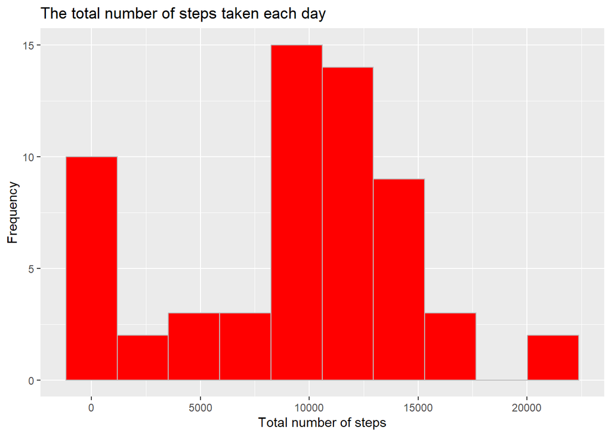

```r
psum <- ggplot(date_sum, aes(date_sum))
psum + geom_histogram(bins = 10,
                      color = "grey",
                      fill = "red") + ggtitle("The total number of steps taken each day") +
        labs(x = "Total number of steps", y = "Frequency")
```

```r
mean_date <- round(mean(date_sum$date_sum))
median_date <- median(date_sum$date_sum)
```

Mean number of steps taken each day is 9354.  
Median number of steps taken each day is 10395.

## 3. What is the average daily activity pattern?

We could use mean of 5 minutes interval data to calculate the daily activity pattern.

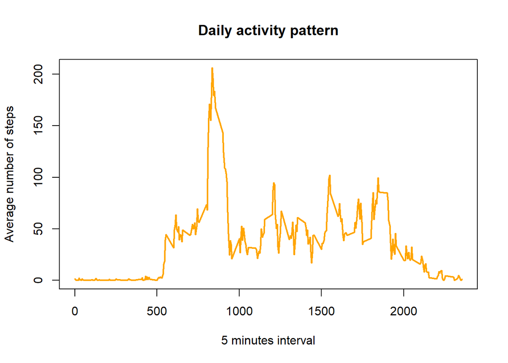

```r
dailyact_mean <-
        tapply(raw_data$steps, raw_data$interval, mean, na.rm = TRUE)
plot(
        y = dailyact_mean,
        x = names(dailyact_mean),
        type = "l",
        lwd = 2,
        col = "orange",
        xlab = "5 minutes interval",
        ylab = "Average number of steps",
        main = "Daily activity pattern"
)
```

## 4. Imputing missing values of data

Missing values of *stpes* in the dataset should be filled by the average value of the 5 minutes interval.

```r
for (i in 1:17568) {
        if (is.na(raw_data[i, "steps"])) {
                interval_serial <- raw_data[i, "interval"]
                raw_data[i, "steps"] <- as.integer(dailyact_mean[as.character(interval_serial)])
        }
}
NA_newnum <- sum(is.na(raw_data$steps))
```

Now, the number of missing value is 0.

## 5. The total number of steps taken each day after missing values are imputed

After imputing the missing values, let’s replot the histogram of the total number of steps each day.

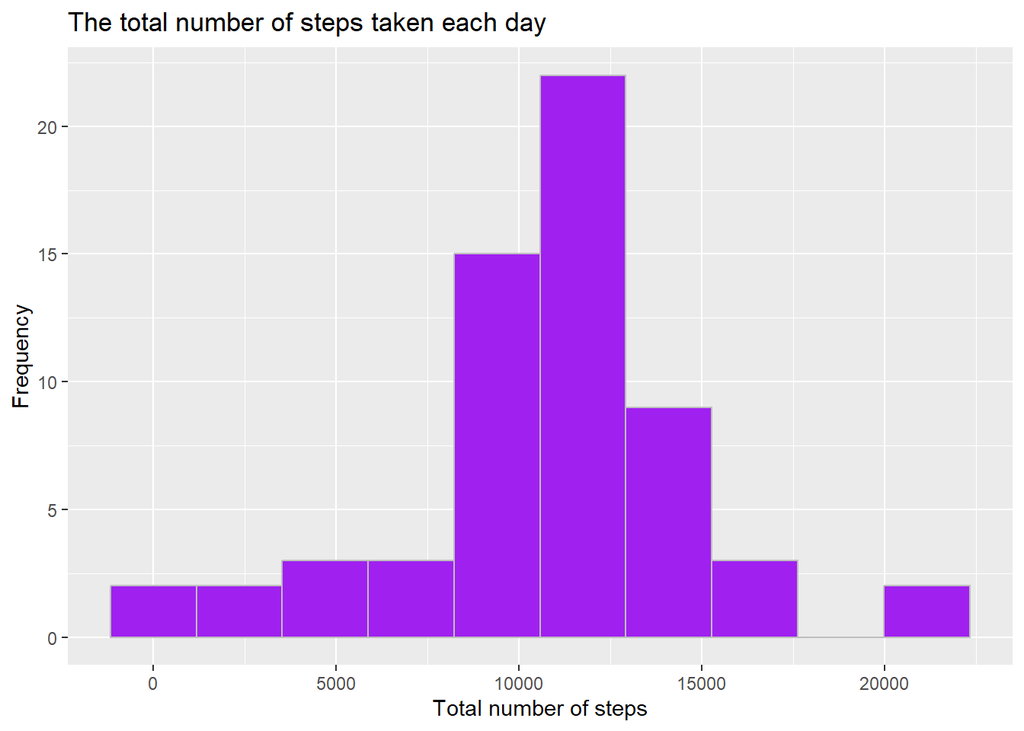

```r
date_sum_new <-
        as.data.frame(tapply(raw_data$steps, raw_data$date, sum))
colnames(date_sum_new) = "date_sum"
psum_new <- ggplot(date_sum_new, aes(date_sum))
psum_new + geom_histogram(bins = 10,
                      color = "grey",
                      fill = "purple") + ggtitle("The total number of steps taken each day") +
        labs(x = "Total number of steps", y = "Frequency")
```

As the new graphic shows, the histogram become more smooth after imputing the missing values.

## 6. The average number of steps taken per 5-minute interval across weekdays and weekends

In order to distinguish the number of steps in weekdays and weekends, we need add a column called weekday. Then subset the dateset twice, the one is weekdays data, another is weedens data.

```r
raw_data <- mutate(raw_data, weekday = wday(raw_data$date))
weekdays_interval <- subset(raw_data, raw_data$weekday > 1.5 & raw_data$weekday < 6.5)
weekends_interval <- subset(raw_data, raw_data$weekday == 1 | raw_data$weekday == 7)
weekdays_mean <-
        tapply(weekdays_interval$steps, weekdays_interval$interval, mean)
weekends_mean <-
        tapply(weekends_interval$steps, weekends_interval$interval, mean)
```

Last, call *plot* to make the comparing graphic.

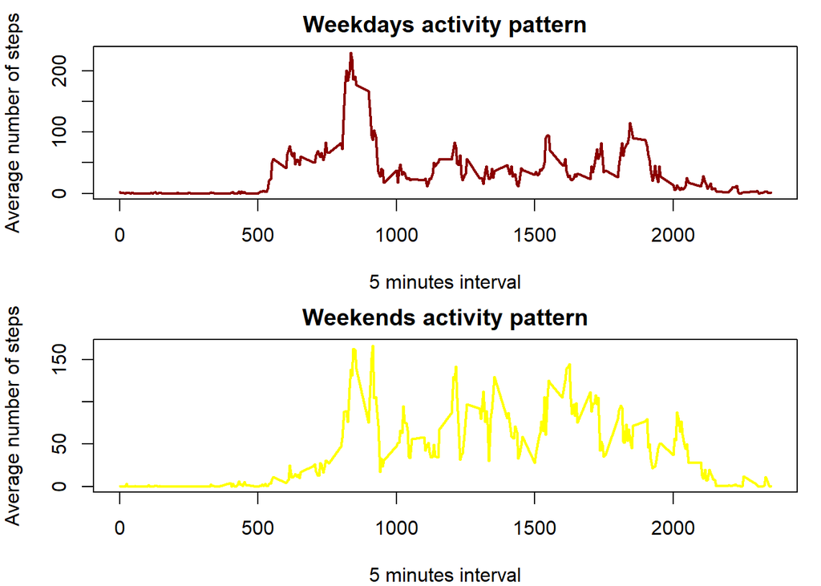

```r
par(mfrow = c(2, 1), mar = c(4, 4, 2, 1))
plot(
        y = weekdays_mean,
        x = names(weekdays_mean),
        type = "l",
        lwd = 2,
        col = "darkred",
        xlab = "5 minutes interval",
        ylab = "Average number of steps",
        main = "Weekdays activity pattern"
)
plot(
        y = weekends_mean,
        x = names(weekends_mean),
        type = "l",
        lwd = 2,
        col = "yellow",
        xlab = "5 minutes interval",
        ylab = "Average number of steps",
        main = "Weekends activity pattern"
)
```